# Multiple Regression Model of Student Academic Achievement

Tristen Bristow

April 6, 2017

### Abstract

#### The interest of this study is in developing a prediction model of student success

#### based on measured factors of success in Mathematics and Porteguese. Multiple

#### regression is applied to develop a regression classifier based on student-provided

#### factors that relate to living conditions and education conditions.

### Source Data

#### The data is downloaded from an archive at:

#### http://archive.ics.uci.edu/ml/machine-learning-databases/00320/student.zip

#### All files are extracted and placed in the same folder as the current script,

#### ‘math score model.R’.

```r
library(car)
library(boot)
c <- read.table("student-por.csv",sep=";",header=TRUE)
c <- data.frame(c)
d <- read.table("student-mat.csv",sep=";",header=TRUE)
d <- data.frame(d)
e <- rbind(c,d)
```

### Data Cleaning

#### Both Math and Porteguese sets are merged, alternate column titles are applied,

#### and student grades are averaged:

```r
names(e) <- c("school","sex","age", "address","family size","parents cohab.", "mom's education",
             "dad's education","mom's job", "dad's job","reason", "guardian","travel", "study",
             "failures","education support","family support","paid","activities", "nursery","higher",
             "internet","romantic","family bond","free time","social","workday alch.","weekend alch.","health",
             "absences","Grade 1","Grade 2","Grade 3")

Grade <- (e$`Grade 1` + e$`Grade 2` + e$`Grade 3`) / 3
e$`Grade 1` <- NULL
e$`Grade 2` <- NULL
e$`Grade 3` <- NULL
e = cbind(e, Grade)
attach(e)
```

### Exploratory Investigation

#### From initial inspection it is clear education success is to be quantified by the Grade variable.

#### Results of inspection indicate general normality of this output variable The class distributions

#### of explanatory variables, ‘dad’s job’ and ‘mom’s job’ factors appear to show questionable value

#### by inspection of the summary table. This is indicated by the limited difference between class-

#### levels, except for the vaguely defined class, ‘other’, showing the survey question isn’t a well-

#### defined or reliable an indicator. An inspection of the VIF’s (Variance Inflation Factors) of model

#### parameters is performed to check for multicolonarity in the dataset.

```r
summary(e)
```

```
##  school   sex          age        address family size parents cohab.
##  GP:772   F:591   Min.   :15.00   R:285   GT3:738     A:121
##  MS:272   M:453   1st Qu.:16.00   U:759   LE3:306     T:923
##                   Median :17.00
##                   Mean   :16.73
##                   3rd Qu.:18.00
##                   Max.   :22.00
##  mom's education dad's education    mom's job      dad's job
##  Min.   :0.000   Min.   :0.000   at_home :194   at_home : 62
##  1st Qu.:2.000   1st Qu.:1.000   health  : 82   health  : 41
##  Median :3.000   Median :2.000   other   :399   other   :584
##  Mean   :2.603   Mean   :2.388   services:239   services:292
##  3rd Qu.:4.000   3rd Qu.:3.000   teacher :130   teacher : 65
##  Max.   :4.000   Max.   :4.000
##         reason      guardian       travel          study
##  course    :430   father:243   Min.   :1.000   Min.   :1.00
##  home      :258   mother:728   1st Qu.:1.000   1st Qu.:1.00
##  other     :108   other : 73   Median :1.000   Median :2.00
##  reputation:248                Mean   :1.523   Mean   :1.97
##                                3rd Qu.:2.000   3rd Qu.:2.00
##                                Max.   :4.000   Max.   :4.00
##     failures      education support family support  paid     activities
##  Min.   :0.0000   no :925           no :404        no :824   no :528
##  1st Qu.:0.0000   yes:119           yes:640        yes:220   yes:516
##  Median :0.0000
##  Mean   :0.2644
##  3rd Qu.:0.0000
##  Max.   :3.0000
##  nursery   higher    internet  romantic   family bond      free time
##  no :209   no : 89   no :217   no :673   Min.   :1.000   Min.   :1.000
##  yes:835   yes:955   yes:827   yes:371   1st Qu.:4.000   1st Qu.:3.000
##                                          Median :4.000   Median :3.000
##                                          Mean   :3.936   Mean   :3.201
##                                          3rd Qu.:5.000   3rd Qu.:4.000
##                                          Max.   :5.000   Max.   :5.000
##      social      workday alch.   weekend alch.       health
##  Min.   :1.000   Min.   :1.000   Min.   :1.000   Min.   :1.000
##  1st Qu.:2.000   1st Qu.:1.000   1st Qu.:1.000   1st Qu.:3.000
##  Median :3.000   Median :1.000   Median :2.000   Median :4.000
##  Mean   :3.156   Mean   :1.494   Mean   :2.284   Mean   :3.543
##  3rd Qu.:4.000   3rd Qu.:2.000   3rd Qu.:3.000   3rd Qu.:5.000
##  Max.   :5.000   Max.   :5.000   Max.   :5.000   Max.   :5.000
##     absences          Grade
##  Min.   : 0.000   Min.   : 1.333
##  1st Qu.: 0.000   1st Qu.: 9.333
##  Median : 2.000   Median :11.333
##  Mean   : 4.435   Mean   :11.267
##  3rd Qu.: 6.000   3rd Qu.:13.333
##  Max.   :75.000   Max.   :19.333
```

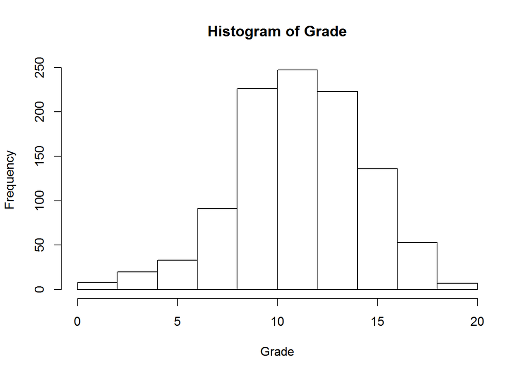

```r
hist(Grade)
```

```r
str(e)
```

```
## 'data.frame':    1044 obs. of  31 variables:
##  $ school           : Factor w/ 2 levels "GP","MS": 1 1 1 1 1 1 1 1 1 1 ...
##  $ sex              : Factor w/ 2 levels "F","M": 1 1 1 1 1 2 2 1 2 2 ...
##  $ age              : int  18 17 15 15 16 16 16 17 15 15 ...
##  $ address          : Factor w/ 2 levels "R","U": 2 2 2 2 2 2 2 2 2 2 ...
##  $ family size      : Factor w/ 2 levels "GT3","LE3": 1 1 2 1 1 2 2 1 2 1 ...
##  $ parents cohab.   : Factor w/ 2 levels "A","T": 1 2 2 2 2 2 2 1 1 2 ...
##  $ mom's education  : int  4 1 1 4 3 4 2 4 3 3 ...
##  $ dad's education  : int  4 1 1 2 3 3 2 4 2 4 ...
##  $ mom's job        : Factor w/ 5 levels "at_home","health",..: 1 1 1 2 3 4 3 3 4 3 ...
##  $ dad's job        : Factor w/ 5 levels "at_home","health",..: 5 3 3 4 3 3 3 5 3 3 ...
##  $ reason           : Factor w/ 4 levels "course","home",..: 1 1 3 2 2 4 2 2 2 2 ...
##  $ guardian         : Factor w/ 3 levels "father","mother",..: 2 1 2 2 1 2 2 2 2 2 ...
##  $ travel           : int  2 1 1 1 1 1 1 2 1 1 ...
##  $ study            : int  2 2 2 3 2 2 2 2 2 2 ...
```

[output cut: 17 more lines]

```r
names(e)
```

```
##  [1] "school"            "sex"               "age"
##  [4] "address"           "family size"       "parents cohab."
##  [7] "mom's education"   "dad's education"   "mom's job"
## [10] "dad's job"         "reason"            "guardian"
## [13] "travel"            "study"             "failures"
## [16] "education support" "family support"    "paid"
## [19] "activities"        "nursery"           "higher"
## [22] "internet"          "romantic"          "family bond"
## [25] "free time"         "social"            "workday alch."
## [28] "weekend alch."     "health"            "absences"
## [31] "Grade"
```

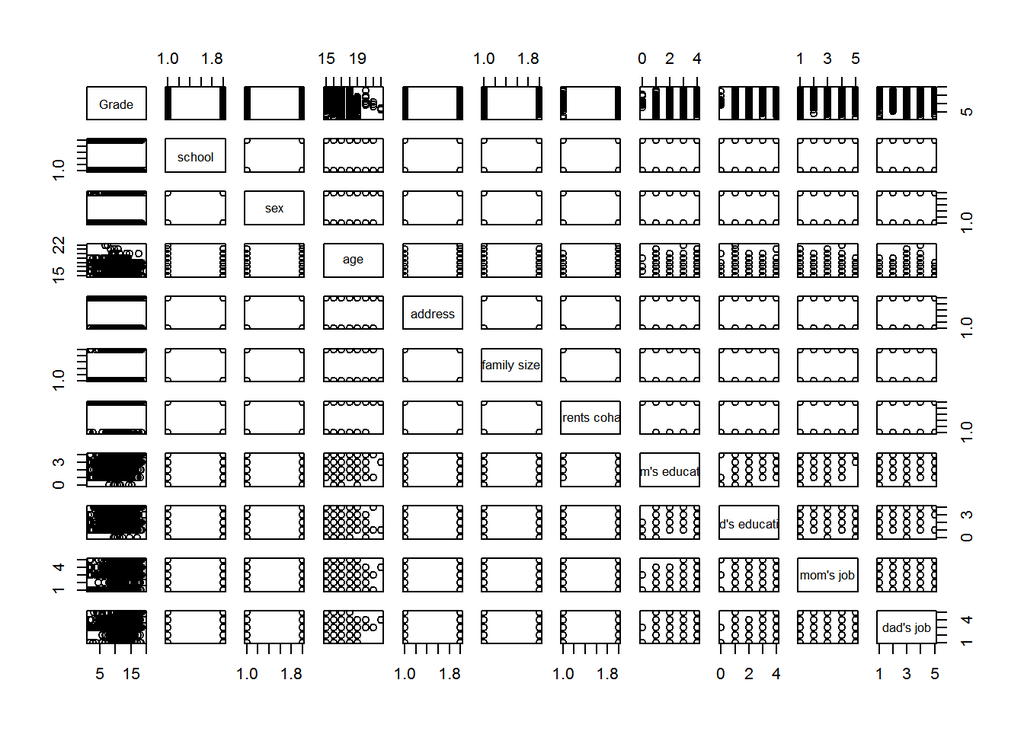

```r
x1 <- e[c(31, 1 : 10)]
pairs(x1)
```

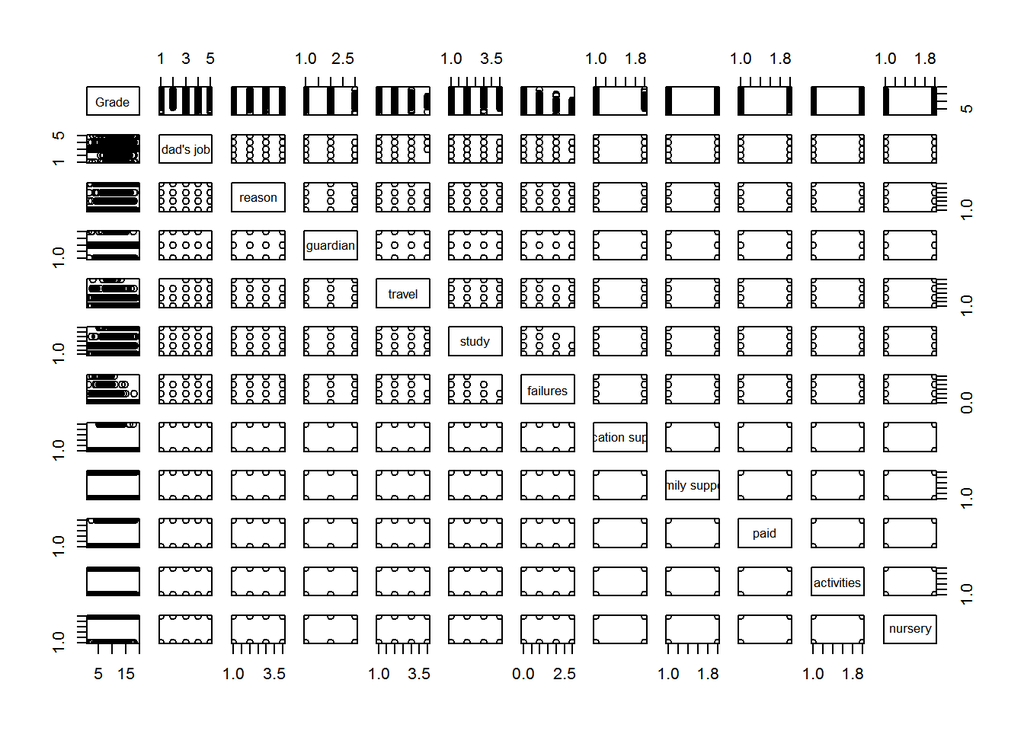

```r
x2 <- e[c(31, 10 : 20)]
pairs(x2)
```

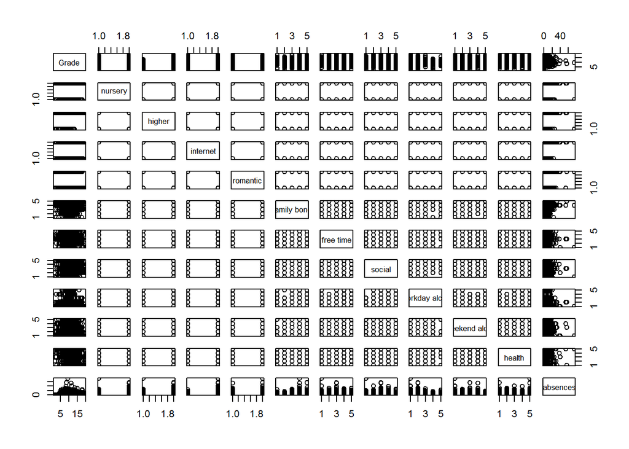

```r
x3 <- e[c(31, 20 : 30)]
pairs(x3)
```

### Training and Test Set Split:

#### The data is randomized to evenly distribute class-occupancy counts so that their

#### proportionalities are better preserved after splitting.

```r
nrtrain <- runif(nrow(e))
dtrain <- e[order(nrtrain),]
train <- dtrain[1 : .75 * nrow(e),]
test <- dtrain[.75 * nrow(e): nrow(e),]
```

```r
names(e)
```

```
##  [1] "school"            "sex"               "age"
##  [4] "address"           "family size"       "parents cohab."
##  [7] "mom's education"   "dad's education"   "mom's job"
## [10] "dad's job"         "reason"            "guardian"
## [13] "travel"            "study"             "failures"
## [16] "education support" "family support"    "paid"
## [19] "activities"        "nursery"           "higher"
## [22] "internet"          "romantic"          "family bond"
## [25] "free time"         "social"            "workday alch."
## [28] "weekend alch."     "health"            "absences"
## [31] "Grade"
```

```r
fit <- glm(Grade~., data = e)
MSE1 <- cv.glm(e, fit, K = 10)$delta[1]
summary(fit)
```

```
##
## Call:
## glm(formula = Grade ~ ., data = e)
##
## Deviance Residuals:
##      Min        1Q    Median        3Q       Max
## -10.8517   -1.4833    0.1019    1.8281    7.8999
##
## Coefficients:
##                         Estimate Std. Error t value Pr(>|t|)
## (Intercept)             9.718585   1.641229   5.922 4.38e-09 ***
## schoolMS               -0.492338   0.235632  -2.089 0.036919 *
## sexM                   -0.065729   0.202918  -0.324 0.746068
## age                     0.030970   0.083072   0.373 0.709372
## addressU                0.240670   0.221106   1.088 0.276645
## `family size`LE3        0.369219   0.199709   1.849 0.064783 .
## `parents cohab.`T       0.023677   0.287473   0.082 0.934375
## `mom's education`       0.173160   0.126079   1.373 0.169925
## `dad's education`       0.042871   0.112327   0.382 0.702792
## `mom's job`health       0.934994   0.442614   2.112 0.034896 *
## `mom's job`other       -0.020608   0.262211  -0.079 0.937372
## `mom's job`services     0.524154   0.310235   1.690 0.091426 .
## `mom's job`teacher     -0.013337   0.410768  -0.032 0.974105
## `dad's job`health      -0.057531   0.600577  -0.096 0.923704
## `dad's job`other       -0.065647   0.386378  -0.170 0.865120
## `dad's job`services    -0.247048   0.404383  -0.611 0.541386
## `dad's job`teacher      1.133663   0.538623   2.105 0.035562 *
## reasonhome              0.133123   0.229150   0.581 0.561410
## reasonother             0.066553   0.311433   0.214 0.830825
## reasonreputation        0.303609   0.239565   1.267 0.205329
## guardianmother         -0.220538   0.219213  -1.006 0.314636
## guardianother           0.217507   0.420273   0.518 0.604896
## travel                 -0.094595   0.132621  -0.713 0.475841
## study                   0.418159   0.115143   3.632 0.000296 ***
## failures               -1.476144   0.148519  -9.939  < 2e-16 ***
## `education support`yes -1.398765   0.286959  -4.874 1.27e-06 ***
## `family support`yes    -0.273525   0.188290  -1.453 0.146627
## paidyes                -0.768545   0.221702  -3.467 0.000549 ***
## activitiesyes           0.097293   0.181423   0.536 0.591887
## nurseryyes             -0.025260   0.222561  -0.113 0.909661
## higheryes               1.409229   0.341220   4.130 3.93e-05 ***
## internetyes             0.323375   0.233715   1.384 0.166780
## romanticyes            -0.448088   0.188898  -2.372 0.017874 *
## `family bond`           0.102933   0.096962   1.062 0.288680
## `free time`             0.032757   0.093005   0.352 0.724759
## social                 -0.218046   0.089048  -2.449 0.014510 *
## `workday alch.`        -0.117328   0.128143  -0.916 0.360092
## `weekend alch.`        -0.008548   0.098360  -0.087 0.930768
## health                 -0.156854   0.063972  -2.452 0.014378 *
## absences               -0.016961   0.014979  -1.132 0.257773
## ---
## Signif. codes:  0 '***' 0.001 '**' 0.01 '*' 0.05 '.' 0.1 ' ' 1
##
## (Dispersion parameter for gaussian family taken to be 7.662112)
##
##     Null deviance: 10806.2  on 1043  degrees of freedom
## Residual deviance:  7692.8  on 1004  degrees of freedom
## AIC: 5129.8
##
## Number of Fisher Scoring iterations: 2
```

#### A report on statistical significance of saturated model coefficients indicates

#### significant (p < 0.01) predctors of Grade to be: study, failures, education,

#### support, paid, and higher.

### MSE for 10-Fold CV of fit of saturated model:

```r
MSE1
```

```
## [1] 8.00742
```

#### A check for multicolinarity by VIF shows negative results, indicating the potential for

#### linear modelling success (conditioned on all GVIF values being less than 10).

```r
vif(fit)
```

```
##                         GVIF Df GVIF^(1/(2*Df))
## school              1.457487  1        1.207264
## sex                 1.378085  1        1.173919
## age                 1.444359  1        1.201815
## address             1.322027  1        1.149794
## `family size`       1.125962  1        1.061114
## `parents cohab.`    1.153808  1        1.074155
## `mom's education`   2.738116  1        1.654725
## `dad's education`   2.077963  1        1.441514
## `mom's job`         2.713832  4        1.132916
## `dad's job`         1.890115  4        1.082832
## reason              1.427053  3        1.061060
## guardian            1.472356  2        1.101547
## travel              1.281912  1        1.132215
## study               1.256347  1        1.120869
## failures            1.292695  1        1.136968
## `education support` 1.133132  1        1.064487
## `family support`    1.145957  1        1.070494
## paid                1.113884  1        1.055407
## activities          1.121040  1        1.058792
## nursery             1.080640  1        1.039538
## higher              1.237127  1        1.112262
## internet            1.225436  1        1.106994
## romantic            1.113774  1        1.055355
## `family bond`       1.115004  1        1.055937
## `free time`         1.252843  1        1.119305
## social              1.433910  1        1.197460
## `workday alch.`     1.857976  1        1.363076
## `weekend alch.`     2.174975  1        1.474780
## health              1.130731  1        1.063359
## absences            1.177898  1        1.085310
```

### Second Fit:

#### Now a lower cardinality model of 5 variables (reported significant) from the saturated

#### model is fitted, all variables included are checked for significance (p < 0.01).

```r
fit2 <- glm(Grade ~ study + failures + `education support` + paid + higher, data = e)
MSE2 <- cv.glm(e, fit2, K = 10)$delta[1]
summary(fit2)
```

```
##
## Call:
## glm(formula = Grade ~ study + failures + `education support` +
##     paid + higher, data = e)
##
## Deviance Residuals:
##      Min        1Q    Median        3Q       Max
## -10.4849   -1.6574    0.0707    1.9185    7.9790
##
## Coefficients:
##                        Estimate Std. Error t value Pr(>|t|)
## (Intercept)              9.2697     0.3692  25.108  < 2e-16 ***
## study                    0.4942     0.1091   4.530 6.57e-06 ***
## failures                -1.6364     0.1415 -11.566  < 2e-16 ***
## `education support`yes  -1.2480     0.2796  -4.463 8.96e-06 ***
## paidyes                 -0.6331     0.2193  -2.887  0.00397 **
## higheryes                1.8935     0.3368   5.622 2.42e-08 ***
## ---
## Signif. codes:  0 '***' 0.001 '**' 0.01 '*' 0.05 '.' 0.1 ' ' 1
##
## (Dispersion parameter for gaussian family taken to be 8.158794)
##
##     Null deviance: 10806.2  on 1043  degrees of freedom
## Residual deviance:  8468.8  on 1038  degrees of freedom
## AIC: 5162.2
##
## Number of Fisher Scoring iterations: 2
```

### 10-Fold CV MSE estimate of Model II:

```r
MSE2
```

```
## [1] 8.227047
```

```r
summary(fit2)
```

```
##
## Call:
## glm(formula = Grade ~ study + failures + `education support` +
##     paid + higher, data = e)
##
## Deviance Residuals:
##      Min        1Q    Median        3Q       Max
## -10.4849   -1.6574    0.0707    1.9185    7.9790
##
## Coefficients:
##                        Estimate Std. Error t value Pr(>|t|)
## (Intercept)              9.2697     0.3692  25.108  < 2e-16 ***
## study                    0.4942     0.1091   4.530 6.57e-06 ***
## failures                -1.6364     0.1415 -11.566  < 2e-16 ***
## `education support`yes  -1.2480     0.2796  -4.463 8.96e-06 ***
## paidyes                 -0.6331     0.2193  -2.887  0.00397 **
## higheryes                1.8935     0.3368   5.622 2.42e-08 ***
## ---
## Signif. codes:  0 '***' 0.001 '**' 0.01 '*' 0.05 '.' 0.1 ' ' 1
##
## (Dispersion parameter for gaussian family taken to be 8.158794)
##
##     Null deviance: 10806.2  on 1043  degrees of freedom
## Residual deviance:  8468.8  on 1038  degrees of freedom
## AIC: 5162.2
##
## Number of Fisher Scoring iterations: 2
```

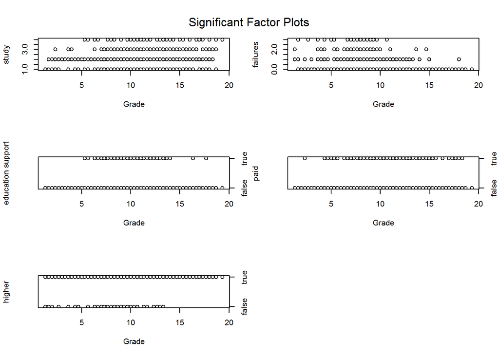

```r
par(mfrow = c(3, 2))

plot(Grade, study)
plot(Grade, failures)
plot(Grade,`education support`, yaxt='n')
axis(4, labels = c("false","true"), at = c(1, 2))
plot(Grade, paid, yaxt='n')
axis(4, labels = c("false","true"), at = c(1, 2))
plot(Grade, higher, yaxt='n')
axis(4, labels = c("false","true"), at = c(1, 2))
mtext("Significant Factor Plots", side = 3, line = -3, outer = TRUE)
#dev.off()
```

### Results

#### This results of this work should be seen as a starting point for more advanced studies

#### of success prediction in general education. They may hold significance for the

#### source data’s originating educational department. It appears strictly domain

#### specific: general claims to any general predictive success of any derived models

#### is not indicated. This is view is surmised from from the collected data and available

#### documentation. The intent interpreted is to find a model of specific factors relevant

#### to learning success that are shared between Mathematics an Portuguese, discussed in

#### identical terms - identical variables are chosen for both data sets as collected from

#### student surveys. This indicates implicit assumption of the study, that a uniform learning

#### measure exists between mathematics and language. This assumption appears to be latent

#### in the work, the chosen factors themselves are more general, living-condition or non-

#### subject specific. Though the apparent study objective appears to provide a general-

#### education predictivemodel, only two categories of education are represented in the data.

#### It is apparent that, for the chosen causal-factors of study, the data is not sufficiently

#### representative to address their generality. In addition, This study has limited data

#### relative to the number of factors of interest, and the number of levels for the chosen

#### factors are also non-trival, (non-binary classes).

### Conclusion

#### subject should be included. It is presumed that, generally, it should be assumed that

#### student success should not be homogenously classed - most students could show uncharactaristic

#### success or failure across specific fields. Such a set of related predictors are expected

#### to show a signifiant degree of statistical non-normality across subjects. This study shows

#### one of the most predictive factors to be a student’s past failure rate, generically defined.

#### This factor should be split into multiple predictors of each acedmic subject category,

#### should more education subject categories be included in a re-designed study. It is

#### expected that this set of related measures will act as a dominant predictor of general

#### education success for an individual student.